# DSA 2021 - TD R

Fabien FAIVRE

21 juin 2021

# 1 Présentation du projet

Dans le cadre de la formation [DSA](https://www.institut-du-risk-management.fr/nos-formations/formations-certifiantes/certificat-data-science-pour-actuariat/), nous avons eu l’occasion d’analyser un jeu de données de tarification MRH à l’occasion d’un Hackathon.

Du fait des ontraintes propres au Hackathon je n’avais pas eu l’occasion de finaliser l’analyse de ce jeu de données. Par ailleurs, pour le hackathon, le choix s’était porté sur le logiciel Python.

Ce TD est donc l’occasion de poursuivre l’analyse de ce jeu de données et d’explorer l’usage de packages et d’approches développés par MV Wütrich et disponible sur le site de l’[association suisse des actuaires](https://www.actuarialdatascience.org/ADS-Lectures/Courses/).

# 2 Analyse

## 2.1 Mise en place de l’environnement

Le code suivant est un ensemble d’utilitaire pour naviguer dans les répertoires relatifs du projet et installer ou charger les packages nécessaires à l’analyse :

```r
if (!require("here")){
  install.packages("here")
  library("here")
}

set_here

LoadPackage <- function (load.lib=c("")) {

  install.lib<-load.lib[!load.lib %in% installed.packages()]
  for(lib in install.lib) install.packages(lib,dependencies=TRUE)
  sapply(load.lib,require,character=TRUE)

}


LoadPackage(c('ggplot2', 'dplyr', 'formattable', 'DT'))
```

# 3 Présentation du jeu de données

Le jeu de données est constitué de 4 fichiers :

```r
list.files(path=here('data', 'raw'))
```

```
## [1] "Data"                  "Data.zip"              "dsa2021_hackathon.zip"
## [4] "expo_test.csv"         "expo_train.csv"        "primes2019.csv"
## [7] "sin_train.csv"
```

Le projet suit un portefeuille d’assurance MRH suivi sur plusieurs années de 2016 à 2018 inclus. L’objectif initial du Hackathon est d’estimer les primes 2019 sur un échantillon de contrats.

## 3.1 expo_train

Le fichier `expo_train.csv` contient la liste des contrats en risques historiquement suivis :

```r
expo_train = read.table(file = here('data', 'raw', 'expo_train.csv'), header=T, sep=',', dec='.', encoding = 'UTF-8', stringsAsFactors = F)

datatable(head(expo_train))
```

|  | X | EXPO | FORMULE | TYPE_RESIDENCE | TYPE_HABITATION | NB_PIECES | SITUATION_JURIDIQUE | NIVEAU_JURIDIQUE | VALEUR_DES_BIENS | OBJETS_DE_VALEUR | ZONIER | NBSIN_TYPE1_AN1 | NBSIN_TYPE1_AN2 | NBSIN_TYPE1_AN3 | NBSIN_TYPE2_AN1 | NBSIN_TYPE2_AN2 | NBSIN_TYPE2_AN3 | id | ANNEE |
| --- | --- | --- | --- | --- | --- | --- | --- | --- | --- | --- | --- | --- | --- | --- | --- | --- | --- | --- | --- |
| 1 | 384538 | 1 | MEDIUM | PRINCIPALE | APPARTEMENT | 1 | PROPRIO | JUR1 | 3500 | NIVEAU_1 | B40 | 0 | 1 | 0 | 0 | 0 | 0 | 5 | 2017 |
| 2 | 441079 | 0.8246574402 | CONFORT | PRINCIPALE | MAISON |  | PROPRIO | JUR1 | 0 | NIVEAU_1 | A11 | 0 | 1 | 0 | 0 | 0 | 0 | 9 | 2018 |
| 3 | 119668 | 1 | ESSENTIEL | PRINCIPALE | APPARTEMENT | 3 | LOCATAIRE | JUR1 | 35000 | NIVEAU_1 | B32 | 0 | 1 | 0 | 0 | 0 | 0 | 11 | 2017 |
| 4 | 5124 | 1 | ESSENTIEL | SECONDAIRE | MAISON | 2 | LOCATAIRE | JUR1 | 9000 | NIVEAU_1 | C24 | 0 | 1 | 0 | 0 | 0 | 0 | 13 | 2018 |
| 5 | 130065 | 1 | ESSENTIEL | PRINCIPALE | MAISON | 1 | LOCATAIRE | JUR1 | 20000 | NIVEAU_1 | C9 | 0 | 1 | 0 | 0 | 0 | 0 | 14 | 2017 |
| 6 | 450830 | 1 | CONFORT | PRINCIPALE | MAISON | 2 | LOCATAIRE | JUR1 | 9000 | NIVEAU_1 | C20 | 0 | 1 | 0 | 0 | 0 | 0 | 15 | 2017 |

```r
str(expo_train)
```

```
## 'data.frame':    155651 obs. of  19 variables:
##  $ X                  : int  384538 441079 119668 5124 130065 450830 151401 296526 71801 360445 ...
##  $ EXPO               : num  1 0.825 1 1 1 ...
##  $ FORMULE            : chr  "MEDIUM" "CONFORT" "ESSENTIEL" "ESSENTIEL" ...
##  $ TYPE_RESIDENCE     : chr  "PRINCIPALE" "PRINCIPALE" "PRINCIPALE" "SECONDAIRE" ...
##  $ TYPE_HABITATION    : chr  "APPARTEMENT" "MAISON" "APPARTEMENT" "MAISON" ...
##  $ NB_PIECES          : int  1 NA 3 2 1 2 2 2 1 3 ...
##  $ SITUATION_JURIDIQUE: chr  "PROPRIO" "PROPRIO" "LOCATAIRE" "LOCATAIRE" ...
##  $ NIVEAU_JURIDIQUE   : chr  "JUR1" "JUR1" "JUR1" "JUR1" ...
##  $ VALEUR_DES_BIENS   : num  3500 0 35000 9000 20000 9000 20000 9000 3500 0 ...
##  $ OBJETS_DE_VALEUR   : chr  "NIVEAU_1" "NIVEAU_1" "NIVEAU_1" "NIVEAU_1" ...
##  $ ZONIER             : chr  "B40" "A11" "B32" "C24" ...
##  $ NBSIN_TYPE1_AN1    : int  0 0 0 0 0 0 1 0 0 0 ...
##  $ NBSIN_TYPE1_AN2    : int  1 1 1 1 1 1 1 1 1 1 ...
##  $ NBSIN_TYPE1_AN3    : int  0 0 0 0 0 0 0 0 0 0 ...
##  $ NBSIN_TYPE2_AN1    : int  0 0 0 0 0 0 0 0 0 0 ...
##  $ NBSIN_TYPE2_AN2    : int  0 0 0 0 0 0 0 0 0 0 ...
##  $ NBSIN_TYPE2_AN3    : int  0 0 0 0 0 0 0 0 0 0 ...
##  $ id                 : int  5 9 11 13 14 15 20 21 28 30 ...
##  $ ANNEE              : int  2017 2018 2017 2018 2017 2017 2018 2016 2018 2016 ...
```

Les données ont été prétraitées pour disposer d’**une ligne par période de risque annuelle homogène**.

Pour des raisons d’anonymisation, les identifiants contrats ont été supprimés de sorte qu’il n’est pas possible de suivre l’évolution du risque d’une période sur l’autre. Pour la même raison, il ne sera pas possible dans la construction des jeux de validation et de test de s’assurer que toute l’expérience d’un même assuré est bien intégralement dans un jeu d’entraînement, de validation ou de test.

La signification des colonnes présentes est la suivante :

- **`X`**: variable non nommée. Il s’agit d’un artefact du processus de création du fichier initial. **On ne la prend pas en compte**
- **`EXPO`** : exposition en année risque du contrat. Sa valeur précalculée pour chaque ligne est comprise entre 0 et 1

```
##     Min.  1st Qu.   Median     Mean  3rd Qu.     Max.
## 0.002732 0.811475 1.000000 0.837278 1.000000 1.000000
```

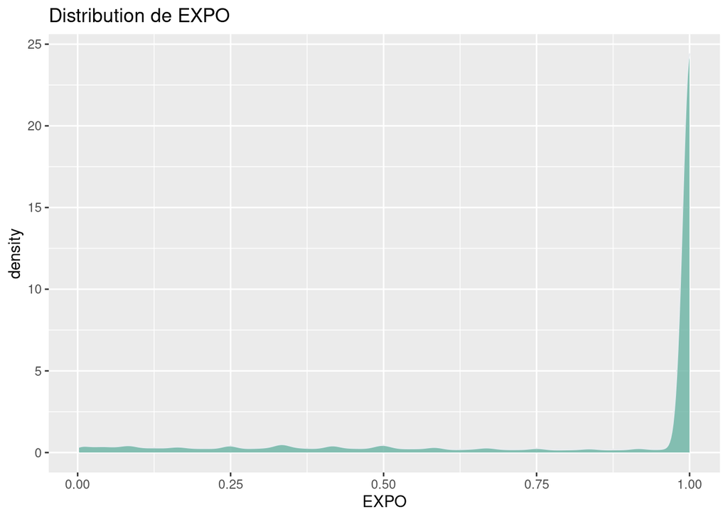

| FORMULE | nb_lignes | EXPO | pct_EXPO |
| --- | --- | --- | --- |
| ALL_INCLUDE | 6,671.00 | 4,759.51 | 3.65% |
| CONFORT | 87,603.00 | 73,930.57 | 56.73% |
| ESSENTIEL | 22,364.00 | 19,546.44 | 15.00% |
| MEDIUM | 39,013.00 | 32,086.59 | 24.62% |

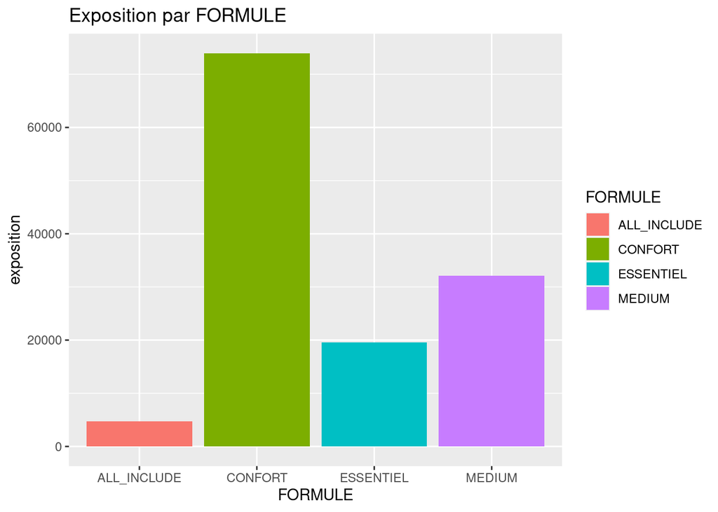

- **`TYPE_RESIDENCE`** : variable catégorielle codant le fait que le bien est une résidence `PRINCIPALE`, ou `SECONDAIRE`

| TYPE_RESIDENCE | nb_lignes | EXPO | pct_EXPO |
| --- | --- | --- | --- |
| PRINCIPALE | 130,727.00 | 112,793.55 | 86.55% |
| SECONDAIRE | 24,924.00 | 17,529.57 | 13.45% |

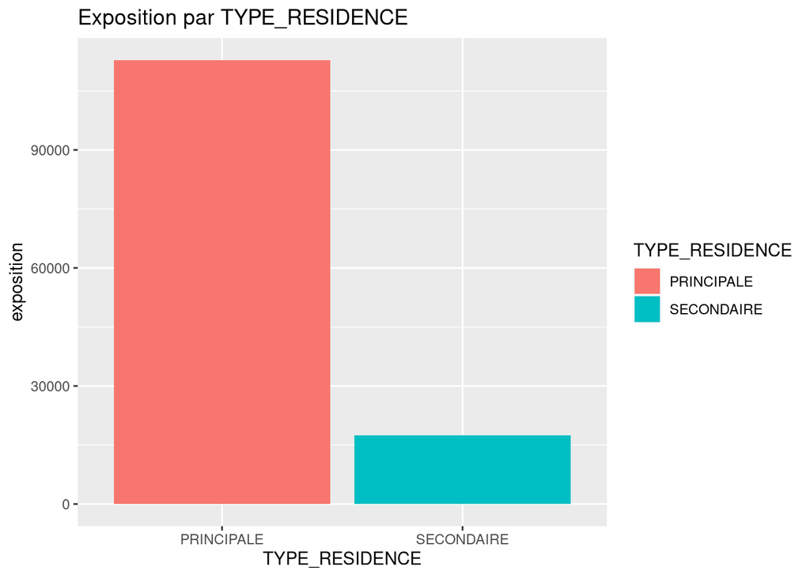

- **`TYPE_HABITATION`** : variable catégorielle codant le fait que le bien est un `APPARTEMENT`, ou une `MAISON`

| TYPE_HABITATION | nb_lignes | EXPO | pct_EXPO |
| --- | --- | --- | --- |
| APPARTEMENT | 71,123.00 | 61,562.82 | 47.24% |
| MAISON | 84,528.00 | 68,760.30 | 52.76% |

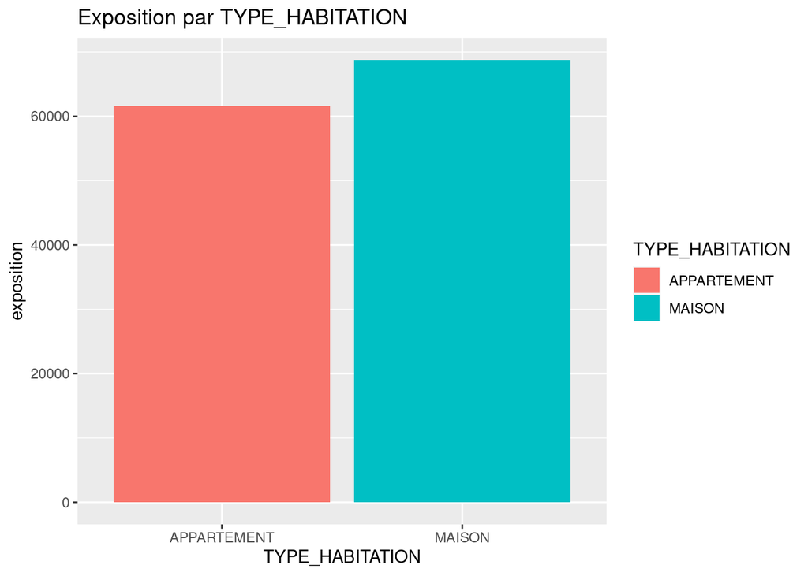

- **`NB_PIECES`** : variable numérique indiquant le nombre de pièces du logement

| NB_PIECES | nb_lignes | EXPO | pct_EXPO |
| --- | --- | --- | --- |
| 0 | 3,718.00 | 2,413.72 | 1.85% |
| 1 | 40,300.00 | 31,943.51 | 24.51% |
| 2 | 60,973.00 | 51,931.99 | 39.85% |
| 3 | 31,695.00 | 27,730.87 | 21.28% |
| 4 | 9,615.00 | 8,495.12 | 6.52% |
| NA | 9,350.00 | 7,807.90 | 5.99% |

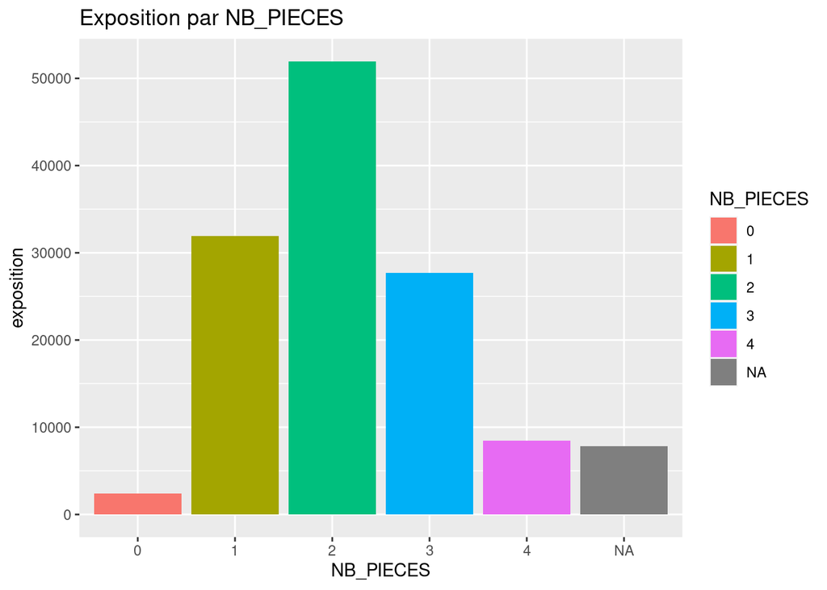

- **`SITUATION_JURIDIQUE`** : variable catégorielle indiquant si le souscripteur est prorpiétaire (`PROPRIO`) ou locataire (`LOCATAIRE`) du logement assuré

| SITUATION_JURIDIQUE | nb_lignes | EXPO | pct_EXPO |
| --- | --- | --- | --- |
| LOCATAIRE | 86,421.00 | 76,135.03 | 58.42% |
| PROPRIO | 69,230.00 | 54,188.09 | 41.58% |

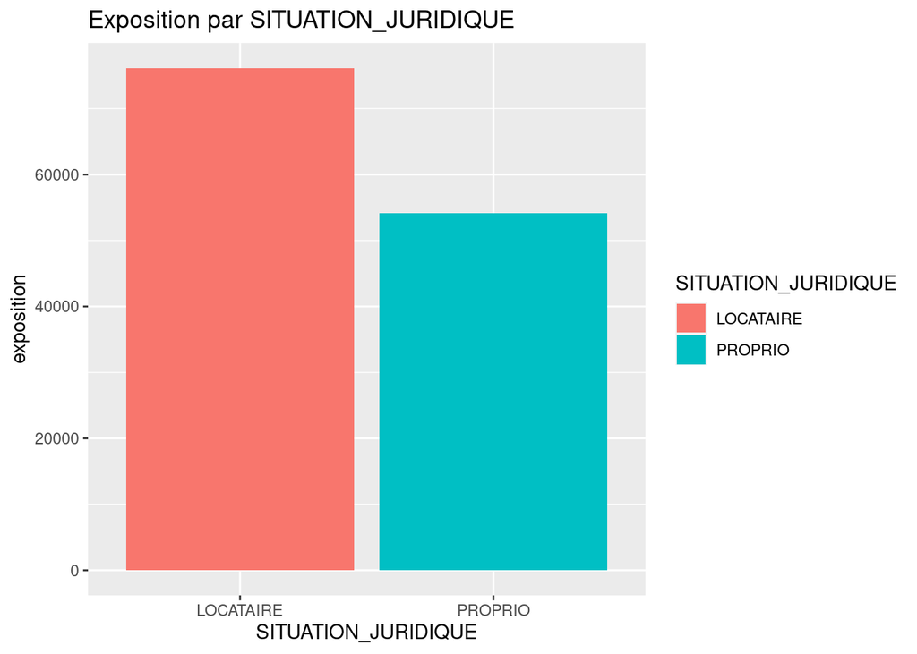

- **`NIVEAU_JURIDIQUE`** : variable catégorielle codant le niveau de couverture de la garantie juridique

| NIVEAU_JURIDIQUE | nb_lignes | EXPO | pct_EXPO |
| --- | --- | --- | --- |
| JUR1 | 153,568.00 | 128,854.03 | 98.87% |
| JUR2 | 2,083.00 | 1,469.09 | 1.13% |

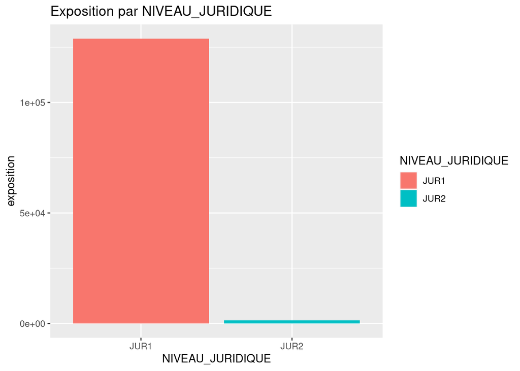

- **`VALEUR_DES_BIENS`** : variable numérique reflétant la valeur couverte du contenu du logement

| VALEUR_DES_BIENS | nb_lignes | EXPO | pct_EXPO |
| --- | --- | --- | --- |
| 0 | 8,307.00 | 5,259.05 | 4.04% |
| 3500 | 51,879.00 | 40,929.10 | 31.41% |
| 9000 | 34,770.00 | 30,059.53 | 23.07% |
| 20000 | 33,745.00 | 29,664.65 | 22.76% |
| 35000 | 11,528.00 | 10,299.00 | 7.90% |
| 50000 | 7,944.00 | 7,243.56 | 5.56% |
| 80000 | 6,534.00 | 6,018.46 | 4.62% |
| 100000 | 944.00 | 849.77 | 0.65% |

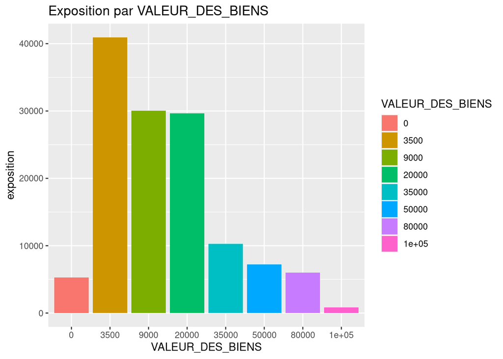

- **`OBJETS_DE_VALEUR`** : variable catégorielle codant le niveau de couverture des objets

| OBJETS_DE_VALEUR | nb_lignes | EXPO | pct_EXPO |
| --- | --- | --- | --- |
| NIVEAU_1 | 145,959.00 | 121,738.34 | 93.41% |
| NIVEAU_2 | 9,692.00 | 8,584.78 | 6.59% |

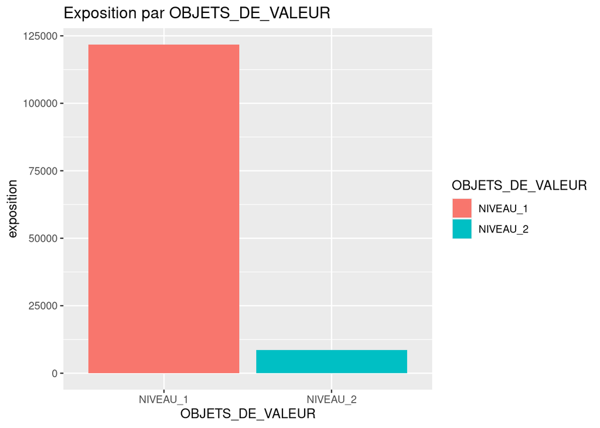

- **`ZONIER`** : variable catégorielle codant la zone du bien assuré. Le code est constitué d’une lettre représentant une zone et d’un nombre représentant une partie de la zone

| ZONIER | nb_lignes | EXPO | pct_EXPO |
| --- | --- | --- | --- |
| A1 | 1,822.00 | 1,579.15 | 1.21% |
| A10 | 1,125.00 | 963.04 | 0.74% |
| A11 | 4,775.00 | 4,140.40 | 3.18% |
| A12 | 3,115.00 | 2,694.44 | 2.07% |
| A13 | 1,879.00 | 1,593.61 | 1.22% |
| A14 | 828.00 | 695.12 | 0.53% |
| A2 | 1,750.00 | 1,466.96 | 1.13% |
| A3 | 1,129.00 | 975.75 | 0.75% |
| A4 | 81.00 | 62.13 | 0.05% |
| A5 | 16.00 | 14.27 | 0.01% |
| A6 | 698.00 | 610.63 | 0.47% |
| A7 | 256.00 | 222.42 | 0.17% |
| A8 | 66.00 | 61.27 | 0.05% |
| A9 | 4,082.00 | 3,526.65 | 2.71% |
| B1 | 793.00 | 701.39 | 0.54% |
| B10 | 3,520.00 | 3,005.74 | 2.31% |
| B11 | 11.00 | 8.94 | 0.01% |
| B12 | 342.00 | 289.71 | 0.22% |
| B13 | 44.00 | 37.32 | 0.03% |
| B14 | 116.00 | 98.55 | 0.08% |
| B16 | 211.00 | 185.81 | 0.14% |
| B17 | 3,530.00 | 2,992.31 | 2.30% |
| B18 | 8.00 | 6.25 | 0.00% |
| B19 | 950.00 | 800.99 | 0.61% |
| B2 | 438.00 | 385.83 | 0.30% |
| B20 | 6.00 | 5.58 | 0.00% |
| B21 | 44.00 | 37.82 | 0.03% |
| B22 | 59.00 | 52.15 | 0.04% |
| B23 | 214.00 | 183.13 | 0.14% |
| B24 | 135.00 | 118.09 | 0.09% |

[output cut: 52 more lines]

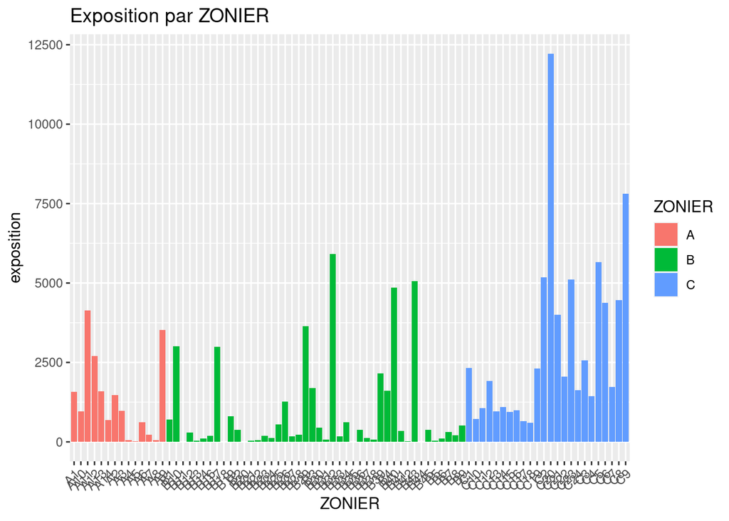

- **`NBSIN_TYPE1_AN1`** : variable numérique indiquant le nombre de sinistre de type 1 l’année précédente

| NBSIN_TYPE1_AN1 | nb_lignes | EXPO | pct_EXPO |
| --- | --- | --- | --- |
| 0 | 145,434.00 | 121,118.77 | 92.94% |
| 1 | 9,378.00 | 8,465.38 | 6.50% |
| 2 | 765.00 | 676.86 | 0.52% |
| 3 | 74.00 | 62.11 | 0.05% |

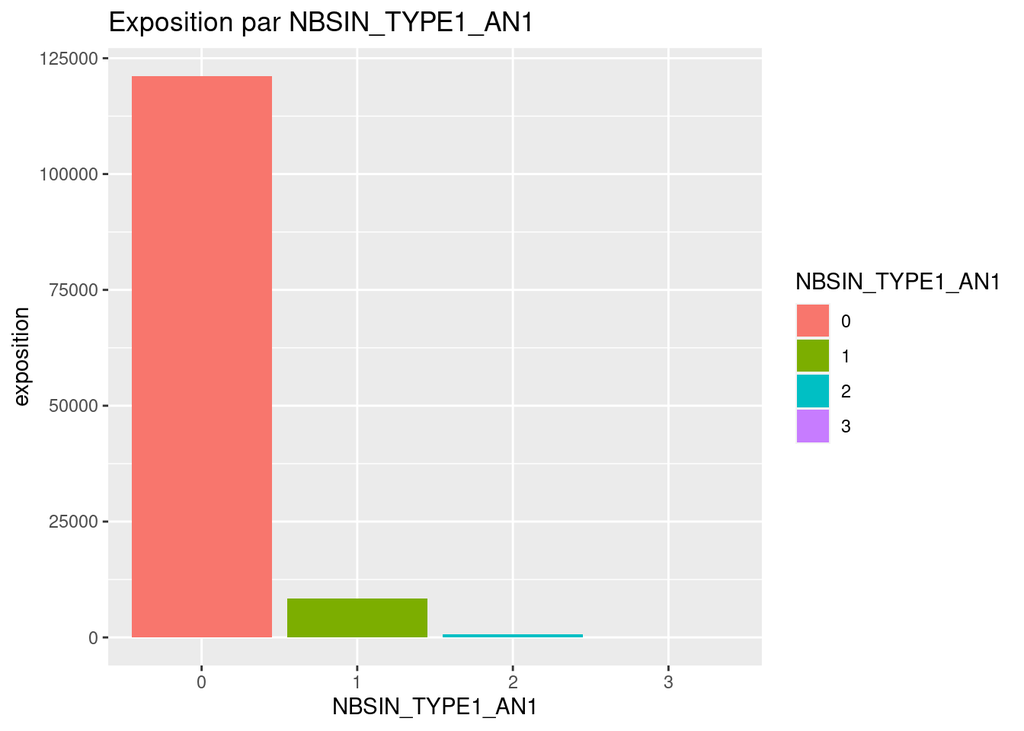

- **`NBSIN_TYPE1_AN2`** : variable numérique indiquant le nombre de sinistre de type 1 il y a 2 ans

**ATTENTION** : comme la table ci-dessous le démontre, cette variable présente un problème puisque toutes les lignes ont au moins un sinistre

Comme discuté dans le hackathon **on ignore cette variable**

| NBSIN_TYPE1_AN2 | nb_lignes | EXPO | pct_EXPO |
| --- | --- | --- | --- |
| 1 | 146,676.00 | 122,175.11 | 93.75% |
| 2 | 8,225.00 | 7,462.01 | 5.73% |
| 3 | 750.00 | 685.99 | 0.53% |

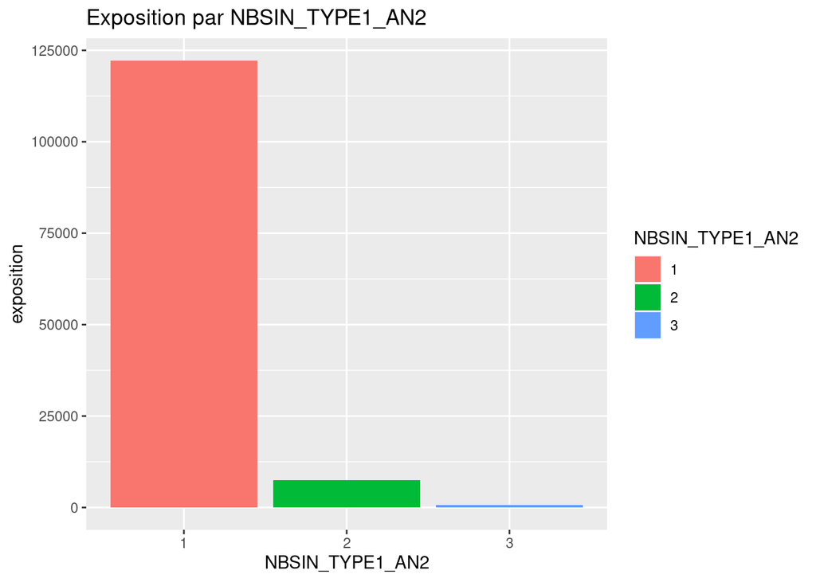

- **`NBSIN_TYPE1_AN3`** : variable numérique indiquant le nombre de sinistre de type 1 il y a 3 ans

| NBSIN_TYPE1_AN3 | nb_lignes | EXPO | pct_EXPO |
| --- | --- | --- | --- |
| 0 | 147,569.00 | 122,889.56 | 94.30% |
| 1 | 7,403.00 | 6,807.03 | 5.22% |
| 2 | 625.00 | 576.62 | 0.44% |
| 3 | 54.00 | 49.91 | 0.04% |

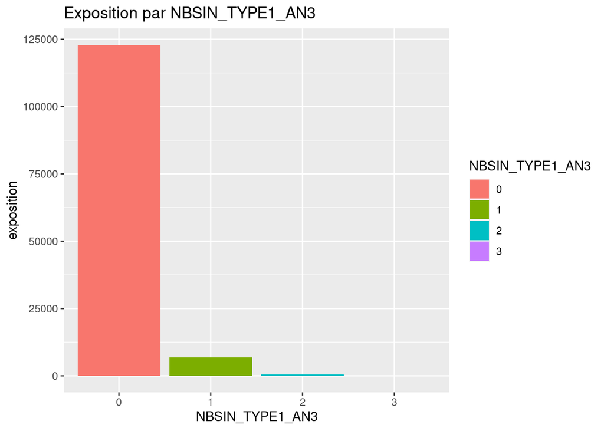

- **`NBSIN_TYPE2_AN1`** : variable numérique indiquant le nombre de sinistre de type 2 l’année précédente

| NBSIN_TYPE2_AN1 | nb_lignes | EXPO | pct_EXPO |
| --- | --- | --- | --- |
| 0 | 152,587.00 | 127,610.08 | 97.92% |
| 1 | 2,870.00 | 2,540.14 | 1.95% |
| 2 | 180.00 | 159.97 | 0.12% |
| 3 | 14.00 | 12.93 | 0.01% |

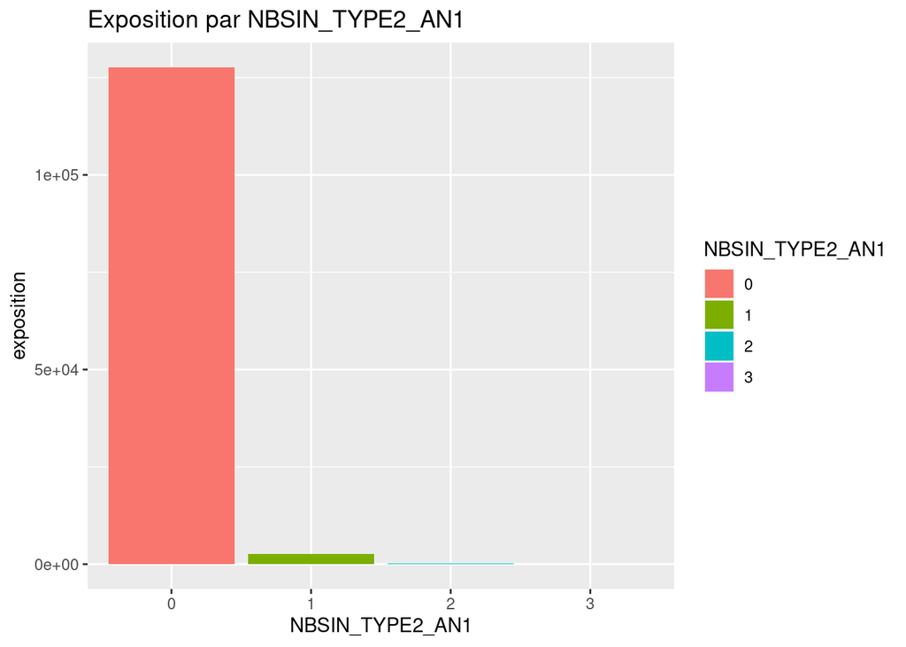

- **`NBSIN_TYPE2_AN2`** : variable numérique indiquant le nombre de sinistre de type 2 il y a 2 ans

| NBSIN_TYPE2_AN2 | nb_lignes | EXPO | pct_EXPO |
| --- | --- | --- | --- |
| 0 | 136,330.00 | 114,011.30 | 87.48% |
| 1 | 2,058.00 | 1,861.63 | 1.43% |
| 2 | 113.00 | 103.72 | 0.08% |
| 3 | 8.00 | 8.00 | 0.01% |
| NA | 17,142.00 | 14,338.46 | 11.00% |

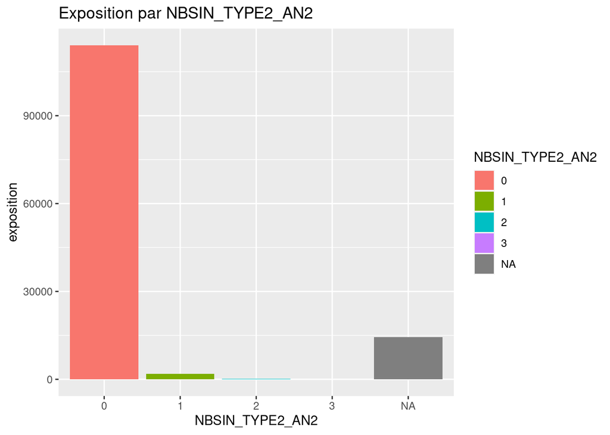

- **`NBSIN_TYPE2_AN3`** : variable numérique indiquant le nombre de sinistre de type 2 il y a 3 ans

| NBSIN_TYPE2_AN3 | nb_lignes | EXPO | pct_EXPO |
| --- | --- | --- | --- |
| 0 | 153,501.00 | 128,360.07 | 98.49% |
| 1 | 2,019.00 | 1,844.33 | 1.42% |
| 2 | 125.00 | 113.36 | 0.09% |
| 3 | 6.00 | 5.37 | 0.00% |

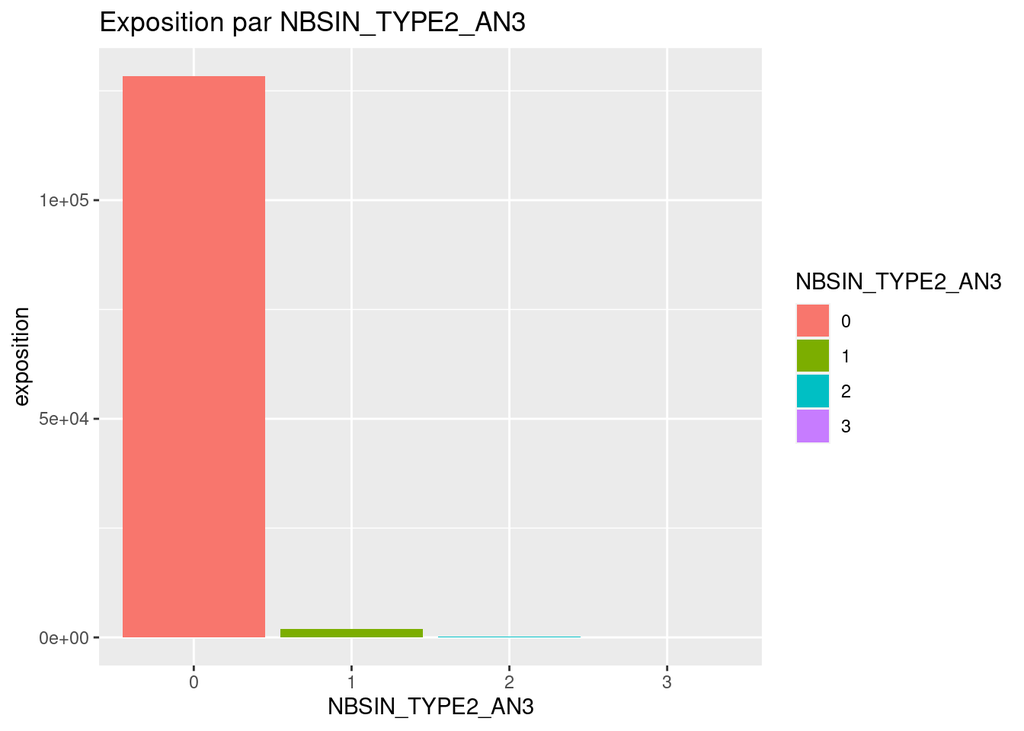

- **`id`** : identifiant du risque, clef de jointure
- **`ANNEE`** : variable catégorielle indiquant l’année d’observation du risque : `2016`, `2017`, `2018`

| ANNEE | nb_lignes | EXPO | pct_EXPO |
| --- | --- | --- | --- |
| 2016 | 54,283.00 | 45,171.85 | 34.66% |
| 2017 | 52,053.00 | 43,654.97 | 33.50% |
| 2018 | 49,315.00 | 41,496.30 | 31.84% |

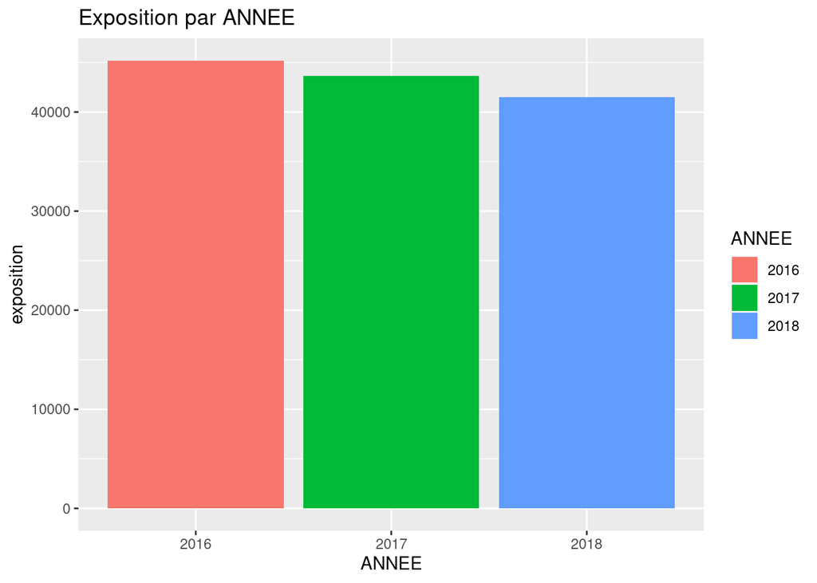

## 3.2 sin_train

```r
sin_train = read.table(file = here('data', 'raw', 'sin_train.csv'), header=T, sep=';', dec=',', encoding = 'UTF-8', stringsAsFactors = F)

datatable(head(sin_train))
```

|  | id | NB | COUT | ANNEE |
| --- | --- | --- | --- | --- |
| 1 | 15 | 1 | 521.43 | 2017 |
| 2 | 277 | 1 | 3000.19 | 2016 |
| 3 | 643 | 1 | 26.33 | 2018 |
| 4 | 668 | 1 | 462.36 | 2017 |
| 5 | 730 | 1 | 640.88 | 2018 |
| 6 | 1816 | 1 | 1547.02 | 2018 |

```r
str(sin_train)
```

```
## 'data.frame':    2693 obs. of  4 variables:
##  $ id   : int  15 277 643 668 730 1816 1852 2061 2270 2322 ...
##  $ NB   : int  1 1 1 1 1 1 1 1 1 1 ...
##  $ COUT : num  521.4 3000.2 26.3 462.4 640.9 ...
##  $ ANNEE: int  2017 2016 2018 2017 2018 2018 2016 2018 2018 2017 ...
```

- **`id`** : identifiant du risque, clef de jointure avec le fichier `expo_train`
- **`NB`** : Nombre de sinistres de la typologie modélisée (inconnue) sur la période d’observation

| NB | nb_lignes |
| --- | --- |
| 1 | 2,613.00 |
| 2 | 79.00 |
| 3 | 1.00 |

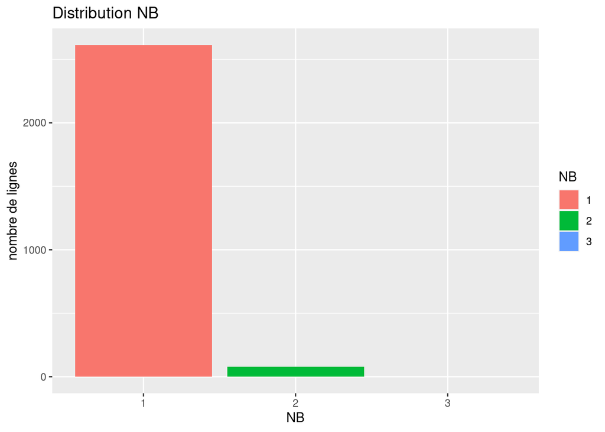